# MaxEnt Hyperparameter Tuning for B. cockerelli Distribution Modeling

Manuel_Cortes

2025-10-15

### MaxEnt Hyperparameter Optimization Using Genetic Algorithm

###### This document implements systematic hyperparameter tuning for MaxEnt models using genetic algorithms (GA) as implemented in SDMtune package. The optimization process explores regularization multipliers (0.2-5.0) and feature class combinations to maximize model performance (AUC) while preventing overfitting through systematic validation procedures.

#### Environment Setup

First, we configure the computational environment for parallel processing and load required packages:

```r
library(future)
library(furrr)
library(parallel)
gc()
```

```
##           used (Mb) gc trigger (Mb) max used (Mb)
## Ncells  589796 31.5    1234687   66   812666 43.5
## Vcells 1058578  8.1    8388608   64  1770328 13.6
```

```r
options(terra.blocks = TRUE)
plan(multisession, workers = 24)

library(terra)
library(SDMtune)
library(readxl)
library(dplyr)
library(tidyverse)
library(raster)
library(geodata)
library(predicts)
library(cluster)
library(ellipse)
library(scatterplot3d)
library(MASS)
library(png)
library(grid)
library(rgl)
library(zeallot)
```

## Section 1: Climate Data Loading and Variable Selection

```r
# Load current climate data (baseline: 1970-2000)
bioclim_data <- rast("C:/Users/manuel.cortes/Desktop/PMP2024/Bactericera/data/2.5 minutos/bioclim_data.tif")
envirem_data <- rast("C:/Users/manuel.cortes/Desktop/PMP2024/Bactericera/ensambles mensuales/envirem_vars_historico.tif")

names(bioclim_data) <- paste0("BIO", 1:nlyr(bioclim_data))

# Combine bioclimatic and environmental variables
climate_data <- c(bioclim_data, envirem_data)
```

```r
# Variable selection based on correlation analysis and ecological relevance
# Selected variables: 2, 5, 6, 12, 21, 22, 26, 34 for B. cockerelli Colombia
selected_variables <- c(2, 5, 6, 12, 21, 22, 26, 34)

# Subset climate data to selected variables
climate_data_subset <- subset(climate_data, selected_variables)
climate_data <- climate_data_subset

# Standardize predictors (mean = 0, sd = 1) for model calibration
climate_data <- scale(climate_data)
```

## Section 2: Presence Data Loading and Preprocessing

We load *B. cockerelli* occurrence records from ICA phytosanitary surveillance (2021-2024) and remove duplicate coordinates to avoid spatial autocorrelation.

```r
# Load presence records from ICA surveillance database
presence_data <- read_excel("C:/Users/manuel.cortes/Desktop/PMP2024/Bactericera/Bactericera cockerelli Colombia Oficial surveillance ICA.xlsx")

# Remove records with missing coordinates
presence_data <- presence_data[!is.na(presence_data$longitude) & !is.na(presence_data$latitude), ]

# Remove duplicate coordinates
presence_data <- presence_data[!duplicated(presence_data[, c("longitude", "latitude")]), ]

# Create presence data frame
presence <- presence_data[, c("longitude", "latitude")]
presence$pa <- 1

# Remove duplicates using dplyr
presence <- presence %>% distinct(longitude, latitude, .keep_all = TRUE)

# Convert to numeric
presence$longitude <- as.numeric(presence$longitude)
presence$latitude <- as.numeric(presence$latitude)
```

## Section 3: Stratified Environmental Sampling for Background Points

We generate background points using stratified sampling in environmental space (PCA-based K-means clustering) to ensure comprehensive representation of environmental gradients while minimizing spatial autocorrelation biases. This approach addresses overfitting issues observed with traditional random geographic sampling.

```r
# Set seed for reproducibility
set.seed(20210707)

# Create spatial vector from presence points
presence_vector <- vect(presence, geom = c("longitude", "latitude"), crs = "epsg:4326")
```

```r
# Crop climate data to Colombia boundaries using GADM
tryCatch({
  colombia_boundary <- gadm(country = "COL", level = 0, path = tempdir())
  climate_crop <- crop(climate_data, colombia_boundary)
  climate_crop <- mask(climate_crop, colombia_boundary)

  # Verify successful crop
  if(all(is.na(values(climate_crop[[1]])))) {
    stop("Error: Colombia crop resulted in NA values")
  }

}, error = function(e) {
  cat("Error downloading Colombia boundaries:", e$message, "\n")
  cat("Attempting alternative method...\n")

  # Alternative method: create approximate Colombia polygon
  colombia_extent <- ext(-82, -66, -5, 13)
  colombia_boundary <- as.polygons(colombia_extent, crs = "epsg:4326")
  climate_crop <- crop(climate_data, colombia_boundary)
  climate_crop <- mask(climate_crop, colombia_boundary)
})
```

```r
# Extract climate values from cropped raster (Colombia)
tryCatch({
  climate_values <- values(climate_crop, na.rm = TRUE)
  climate_coords <- xyFromCell(climate_crop, which(!is.na(values(climate_crop[[1]]))))

  # Verify data extraction
  if(nrow(climate_coords) == 0) {
    stop("Error: No valid coordinates found")
  }

  cat("Valid pixels found:", nrow(climate_coords), "\n")

}, error = function(e) {
  stop("Error extracting climate values: ", e$message)
})
```

```
## Valid pixels found: 54539
```

```r
# Remove rows with NA values
complete_cases <- complete.cases(climate_values)
climate_values_clean <- climate_values[complete_cases, ]
climate_coords_clean <- climate_coords[complete_cases, ]

cat("Pixels after removing NA:", nrow(climate_coords_clean), "\n")
```

```
## Pixels after removing NA: 54539
```

```r
# Verify sufficient data for sampling
if(nrow(climate_values_clean) < nrow(presence)) {
  stop("Error: Insufficient valid pixels for sampling")
}
```

### Principal Component Analysis and K-means Clustering

We perform PCA in environmental space followed by K-means clustering to create environmental strata for background point sampling.

```r
# Principal Component Analysis (PCA) in environmental space
tryCatch({
  climate_pca <- prcomp(climate_values_clean, scale. = TRUE, center = TRUE)
  cat("PCA completed. Variance explained PC1-3:",
      round(sum(climate_pca$sdev[1:3]^2)/sum(climate_pca$sdev^2)*100, 2), "%\n")
}, error = function(e) {
  stop("Error in PCA: ", e$message)
})
```

```
## PCA completed. Variance explained PC1-3: 88.04 %
```

```r
# Extract first 3 principal components
pca_scores <- climate_pca$x[, 1:3]

# K-means clustering in environmental space (PCA)
n_clusters <- min(50, nrow(presence) * 2, nrow(climate_values_clean) %/% 10)
cat("Number of clusters to use:", n_clusters, "\n")
```

```
## Number of clusters to use: 50
```

```r
tryCatch({
  kmeans_result <- kmeans(pca_scores, centers = n_clusters, nstart = 25, iter.max = 100)
  cat("Clustering completed\n")
}, error = function(e) {
  cat("Error in clustering, reducing number of clusters...\n")
  n_clusters <- min(20, nrow(presence))
  kmeans_result <- kmeans(pca_scores, centers = n_clusters, nstart = 10)
})
```

```
## Clustering completed
```

```r
# Assign each pixel to environmental cluster
cluster_assignments <- kmeans_result$cluster

# Calculate number of points per cluster (proportional to cluster size)
cluster_counts <- table(cluster_assignments)
samples_per_cluster <- round((cluster_counts / sum(cluster_counts)) * nrow(presence))

# Ensure minimum total number of samples
if(sum(samples_per_cluster) < nrow(presence)) {
  diff_needed <- nrow(presence) - sum(samples_per_cluster)
  largest_clusters <- order(cluster_counts, decreasing = TRUE)[1:diff_needed]
  samples_per_cluster[largest_clusters] <- samples_per_cluster[largest_clusters] + 1
}

# Stratified sampling by environmental cluster
background_indices <- c()

for(i in 1:n_clusters) {
  if(samples_per_cluster[i] > 0) {
    cluster_pixels <- which(cluster_assignments == i)
    if(length(cluster_pixels) >= samples_per_cluster[i]) {
      sampled_indices <- sample(cluster_pixels, samples_per_cluster[i], replace = FALSE)
    } else {
      sampled_indices <- cluster_pixels
    }
    background_indices <- c(background_indices, sampled_indices)
  }
}

# Create background object with selected coordinates
background <- climate_coords_clean[background_indices, ]
colnames(background) <- c("x", "y")
background <- as.data.frame(background)

# Create absence data frame
absence <- as.data.frame(background)
colnames(absence) <- c("longitude", "latitude")
absence$pa <- 0

# Convert presence coordinates to numeric
presence$latitude <- as.numeric(presence$latitude)
presence$longitude <- as.numeric(presence$longitude)

# Combine presence and absence points
all_points <- rbind(presence, absence)
```

## Section 4: Buffer-Based Environmental Data Extraction

We create 500-meter buffers around presence and background points to extract mean environmental values, reducing spatial autocorrelation in model calibration.

```r
# Convert meters to degrees (latitude-dependent for longitude)
rad_to_deg <- function(rad) rad * 180 / pi
deg_to_rad <- function(deg) deg * pi / 180

# Earth radius in meters
earth_radius <- 6371000

# Convert 250 meters to degrees of latitude (constant)
lat_degree <- 250 / (pi / 180 * earth_radius)

# Convert 250 meters to degrees of longitude (latitude-dependent)
lon_degree <- 250 / (pi / 180 * earth_radius * cos(deg_to_rad(presence$latitude)))

# Average buffer width
avg_width <- (lat_degree + mean(lon_degree)) / 2

# Generate buffers with adjusted width
presence_vect <- vect(presence, geom = c("longitude", "latitude"), crs = "epsg:4326")
presence_buffer <- buffer(presence_vect, width = avg_width)

background_vect <- vect(absence, geom = c("longitude", "latitude"), crs = "epsg:4326")
background_buffer <- buffer(background_vect, width = avg_width)
```

```r
# Extract climate data for presence and background buffers (mean values)
presence_climate <- extract(climate_data, presence_buffer, fun = mean, na.rm = TRUE)
background_climate <- extract(climate_data, background_buffer, fun = mean, na.rm = TRUE)

# Combine climate data with original points
presence_climate <- cbind(presence, presence_climate)
background_climate <- cbind(absence, background_climate)

# Combine presence and background data with climate values
points_climate <- rbind(presence_climate, background_climate)

# Remove coordinate columns before modeling
drop_cols <- which(colnames(points_climate) %in% c("longitude", "latitude", "ID"))
points_climate <- points_climate[, -drop_cols]

# Create response vector (presence/absence)
response <- points_climate$pa
```

## Section 5: Data Preparation for MaxEnt Model Calibration

We prepare presence and background data in SDMtune format (SWD objects) for MaxEnt model training. The `prepareSWD` function creates Species-With-Data objects that link occurrence points with environmental predictors.

```r
# Prepare data in SDMtune format (Species With Data - SWD)
data <- prepareSWD(species = "B. cockerelli Mesoscale",
                   p = presence[, c("longitude", "latitude")],
                   a = absence[, c("longitude", "latitude")],
                   env = climate_data)
```

## Section 6: Data Partitioning Strategy

We partition data into training (70%), validation (15%), and test (15%) sets.

### Critical Distinction:

This three-way split prevents data leakage and ensures robust performance estimates, as the validation set provides independent assessment of the optimized model’s generalization capacity.

```r
# Create training, test, and validation datasets
datasets <- trainValTest(data, val = 0.15, test = 0.15, only_presence = FALSE, seed = 12345)

train <- datasets[[1]]  # Training data (70%) - for model calibration
test <- datasets[[2]]   # Test data (15%) - for hyperparameter optimization
val <- datasets[[3]]    # Validation data (15%) - for final performance metrics
```

## Section 7: Baseline MaxEnt Model Training

We train an initial MaxEnt model with default parameters (regularization = 1.0, all feature classes enabled) to establish baseline performance before systematic hyperparameter optimization.

```r
# Train baseline MaxEnt model with default parameters
model <- train("Maxent", data = train, iter = 700)
```

## Section 8: Hyperparameter Grid Definition

We define the hyperparameter search space for genetic algorithm optimization:

### Feature Classes (fc)

Define mathematical transformations of predictors: - **l** = linear: Simple linear relationships - **q** = quadratic: Polynomial relationships (degree 2) - **p** = product: Interaction terms between variables - **t** = threshold: Step functions - **h** = hinge: Piecewise linear functions - Combinations: 31 possible feature class combinations tested

```r
# Define hyperparameter grid for optimization
h <- list(reg = seq(0.2, 5, 0.2),
          fc = c("l", "q", "p", "t", "h", "lq", "lp", "lt", "lh", "qp", "qt", "qh",
                 "pt", "ph", "th", "lqp", "lqt", "lqh", "lpt", "lph", "lth", "qpt",
                 "qph", "qth", "pth", "lqpt", "lqph", "lqth", "lpth", "qpth", "lqpth"))
```

## Section 9: Genetic Algorithm Optimization

We optimize MaxEnt hyperparameters using genetic algorithm (GA) implementation from SDMtune package.

### Genetic Algorithm Process:

1. **Initial Population (pop = 37)**: Creates 37 candidate models with random hyperparameter combinations
2. **Fitness Evaluation**: Each model is evaluated on the TEST SET using AUC as fitness metric
3. **Evolutionary Generations (gen = 5)**: Iterative evolution through selection, crossover, mutation, and evaluation
4. **Convergence**: Each generation improves upon previous best configurations

The genetic algorithm explores hyperparameter space more efficiently than exhaustive grid search, focusing on promising regions of parameter space.

```r
# Optimize hyperparameters using genetic algorithm
opt_model <- optimizeModel(
  model = model,
  hypers = h,
  metric = "auc",
  test = test,        # Test set used for optimization (fitness evaluation)
  pop = 37,           # Initial population size (37 candidate models)
  gen = 5,            # Number of evolutionary generations
  seed = 12345
)
```

## Section 10: Best Model Selection and Ensemble Creation

We select the best model configuration based on highest test AUC from genetic algorithm optimization. The `combineCV` function creates an ensemble by averaging predictions from the top-performing hyperparameter combinations, resulting in more stable and generalizable predictions.

```r
# Select best model based on highest test AUC
best_model <- combineCV(opt_model@models[[which.max(opt_model@results$test_AUC)]])
```

## Section 11: Model Performance Evaluation

### Performance Metrics:

```r
# Calculate True Skill Statistic (TSS)
tss_value <- tss(best_model)
cat("True Skill Statistic (TSS):", tss_value, "\n")
```

```
## True Skill Statistic (TSS): 0.9686411
```

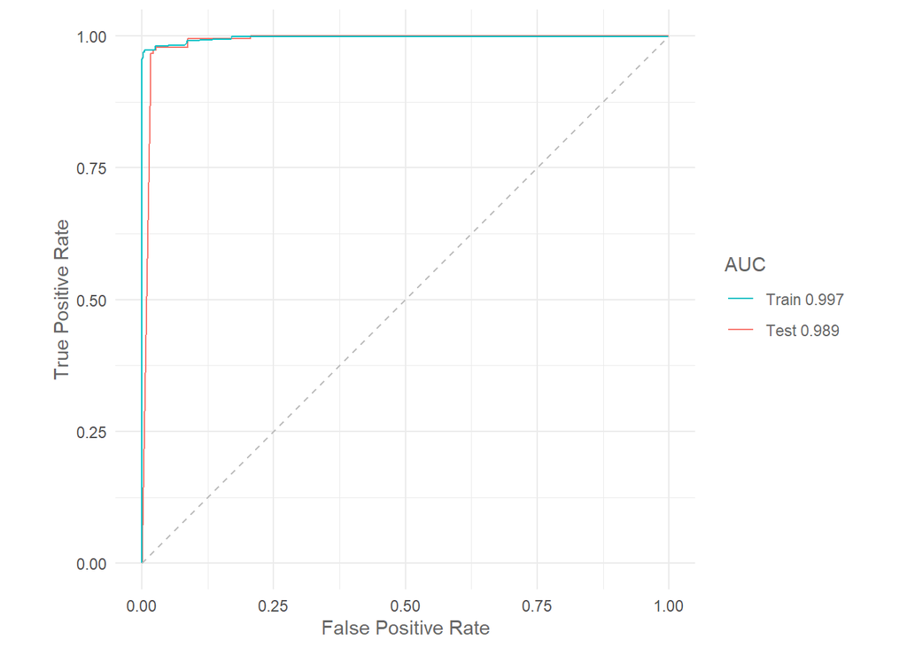

```r
# Plot ROC curve and calculate AUC using test set
roc_plot <- plotROC(best_model, val)
plot(roc_plot)
```

## Section 12: Variable Importance Analysis - Jackknife Test

Jackknife analysis systematically evaluates predictor importance by:

1. Training models with each variable excluded (one at a time)
2. Training models with only individual variables
3. Comparing performance (AUC) to identify most influential predictors

This approach reveals variables with highest individual predictive capacity and those whose exclusion most reduces model performance.

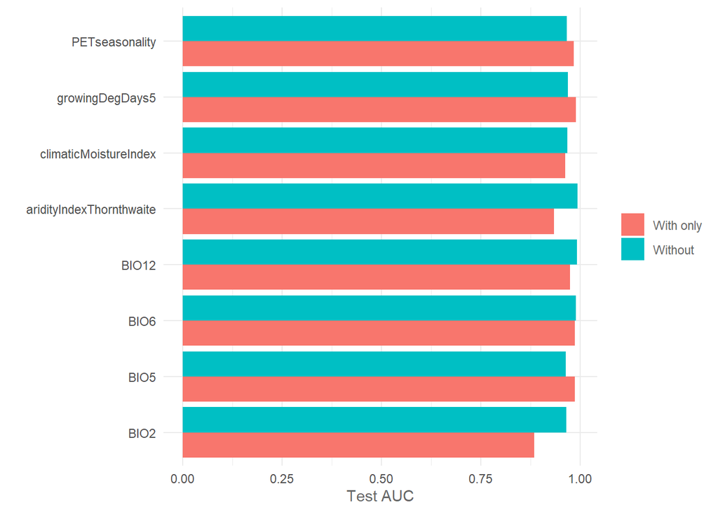

```r
# Perform Jackknife test for variable importance
jk <- doJk(best_model,
           metric = "auc",
           test = val)  # Use validation set for importance evaluation

# Visualize Jackknife results
jk_plot <- plotJk(jk, type = "test")
plot(jk_plot)
```

## Section 13: Variable Correlation Visualization

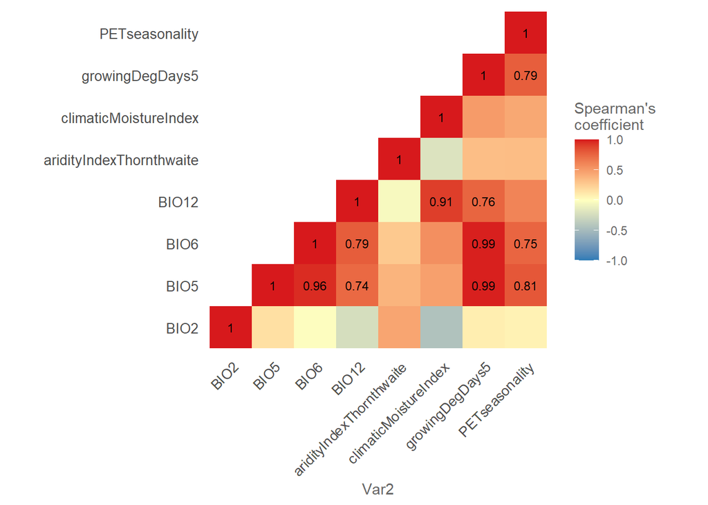

```r
# Visualize correlation matrix for selected variables
correlation_plot <- plotCor(train, method = "spearman", cor_th = 0.7)
plot(correlation_plot)
```